# 2017년 대선 결과 낯선 시각화 (3자구도) 예제

@nobody_indepth

5/17/2017

# 동기

이 예제를 작성하게 된 계기는 [3자구도를 산포도로 그리다가 잘못된 오류지적 포스팅](https://www.facebook.com/sh.matthewK/posts/1328130073940328)을 보고 나서다. 글에서 지적했듯이 2차원 산포도를 그릴 때 문제는 숨겨진 변수의 효과때문에 잘못된 분석을 한다는데 있다.

이에 여러 한계가 있지만, ternary plot란 시각화가 도움이 될 수가 있다. 이 plot는 3가지 구성요소로 이뤄진 광물분석에 많이들 이용했다고 하는데, 자세히 해석하려고 들면 쫌 복잡해지는 면이 있지만 전체적인 3자구도를 조감하는데는 꽤 유용한 방법이다. 자세한 사항은 [위키피디아 항목](https://en.wikipedia.org/wiki/Ternary_plot)을 참조하시라. 이 예제는 ggtern package를 쓴다[^1]

# 시군구별 3자구도 시각화

우선 앞의 동기가 되었던대로 시군구별 주요 3후보를 표시해보기로 하자.

그리기에 앞서서 최소한의 돌다리 두들기기를 하자. 즉, top 3 후보들의 득표율이 전체득표율에 차지하는 비중을 보는 것이다. 아무리 소수정당후보라고 하더라도 일부 시군구에서 유승민, 심상정후보의 득표율 합계가 15%를 넘는 경우가 있다는 것을 확인할 수 있다. 이러면 아무래도 왜곡이 일어날 수밖에 없다.

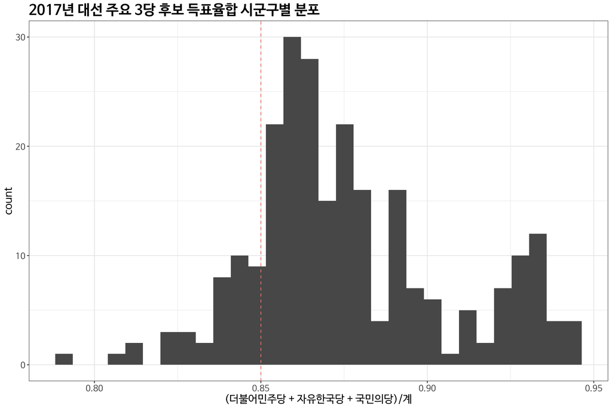

해당 시군구는 어떤 곳들인가? 250개 시군구 중 36개 시군구들이다. 목록을 보면 아래와 같다.

2017년 대선 시군구별 1-3당 득표율 합계가 85% 미만인 지역들

| 광역 | 시군구 | 유승민 | 심상정 |
| --- | --- | --- | --- |
| 서울특별시 | 용산구 | 8.01% | 6.62% |
| 서울특별시 | 마포구 | 7.44% | 7.73% |
| 서울특별시 | 서초구 | 10.01% | 5.67% |
| 서울특별시 | 강남구 | 9.92% | 5.56% |
| 대구광역시 | 중구 | 11.42% | 4.56% |
| 대구광역시 | 동구 | 15.88% | 4.22% |
| 대구광역시 | 남구 | 10.41% | 4.50% |
| 대구광역시 | 북구 | 12.31% | 5.02% |
| 대구광역시 | 수성구 | 13.57% | 4.49% |
| 대구광역시 | 달성군 | 11.63% | 5.31% |
| 대구광역시 | 달서구 | 12.22% | 5.04% |
| 인천광역시 | 연수구 | 7.68% | 7.05% |
| 울산광역시 | 중구 | 7.94% | 7.88% |
| 울산광역시 | 남구 | 8.48% | 7.35% |
| 울산광역시 | 동구 | 7.69% | 10.68% |
| 울산광역시 | 북구 | 8.17% | 10.55% |
| 울산광역시 | 울주군 | 8.12% | 6.86% |
| 경기도 | 수원시영통구 | 8.41% | 6.87% |
| 경기도 | 성남시분당구 | 9.00% | 6.05% |
| 경기도 | 평택시 | 7.09% | 7.39% |
| 경기도 | 고양시덕양구 | 6.30% | 10.52% |
| 경기도 | 고양시일산동구 | 7.45% | 8.15% |
| 경기도 | 고양시일산서구 | 7.28% | 7.69% |
| 경기도 | 과천시 | 8.25% | 6.92% |
| 경기도 | 파주시 | 6.57% | 7.90% |
| 강원도 | 인제군 | 8.11% | 6.38% |
| 강원도 | 화천군 | 8.53% | 6.59% |
| 강원도 | 양구군 | 8.76% | 6.43% |
| 충청남도 | 천안시서북구 | 6.91% | 7.84% |
| 경상북도 | 포항시북구 | 10.21% | 5.67% |
| 경상북도 | 포항시남구 | 9.59% | 5.90% |
| 경상북도 | 구미시 | 10.38% | 6.53% |
| 경상북도 | 경산시 | 11.24% | 5.35% |
| 경상북도 | 칠곡군 | 9.86% | 6.04% |
| 경상남도 | 창원시성산구 | 8.20% | 7.09% |
| 제주특별자치도 | 제주시 | 6.21% | 8.68% |

이를 해소하는 방법은 여러가지가 있을 수 있다. 예를 들어 범보수후보로 홍준표와 유승민을 묶고, 진보쪽으론 문재인과 심상정을 묶어볼 수도 있겠지만, 이런 묶음에는 이론의 여지들도 있다. 예를 들어 내년 지방선거때 구도를 상상해볼 때는 정당별 연합관계 여부에 따라서 위와 같이 묶어서 계산해볼 수도 있을 것이다.

이 예제에선 단순히 해당 시군구에 별표를 치고 그대로 보여주기로 한다. 즉, 각 시군구에서 3당 후보들이 득표한 득표수만을 놓고 “3당득표율”을 계산해서 이에 대해 ternary plot를 그려보자. 색칠은 권역별로 했는데, 이러니까 아주 분명한 패턴을 확인할 수 있다. 호남권역은 홍준표 득표율이 미미하고 문재인에 기울어졌지만 비교적 큰 분산의 득표율을 보여준 것, 영남의 경우는 홍준표만큼은 아니고 어느 정도 안철수의 득표율이 있는 가운데 홍준표가 강세인 지역과 문재인과 홍준표가 비등한 지역으로 갈린다는 것이다. 반대로 수도권은 살짝 문재인에게 기운 3자구도이며 충청지역은 이보다는 약간 문재인의 세가 약하되 크게 안철수쪽으로 이동하진 않았다는 점 등이 보인다.

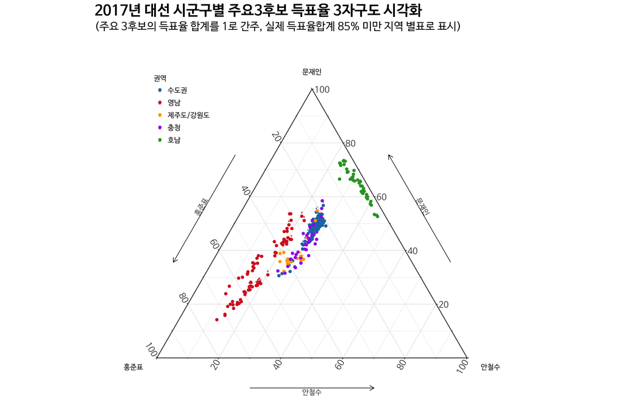

이렇듯 변형된 산포도 그래프는 3자구도에 꽤 좋은 모습을 보여준다. 이러면 바로 더 들어가서, 영남지역에서도 혹시 광역으로 득표율이 갈리는지 좀더 살펴볼 수도 있다. 경북지역은 홍준표 강세에 안철수가 경남보다 좀더 강했고, 부산과 울산은 좀더 문재인쪽으로 가 있는 것을 확인할 수 있다.

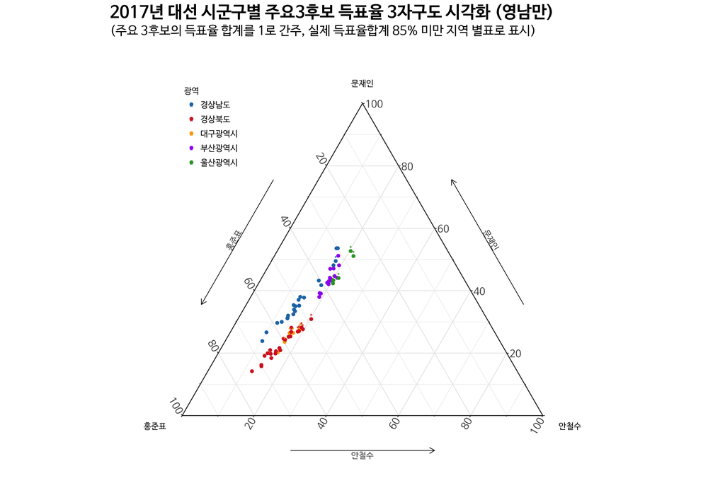

사실 각 시군구별로 득표수는 훨씬 더 크게 차이가 난다. 따라서 유권자수가 많은 시군구에 비해 유권자수가 적은 시군구가 과대대표되는 한계가 있다. 이 정보를 ternary plot방식에 더 집어넣을 수 있을까? 점의 크기를 달리하는 방법이 있겠다. 물론 정확하게 숫자에 비례하면 좋겠지만 여러가지 사정상 적절한 구간으로 나누어서 크기를 달리해봤다. 경남의 몇몇 중량감 있는 시군구가 좀더 잘 보인다.

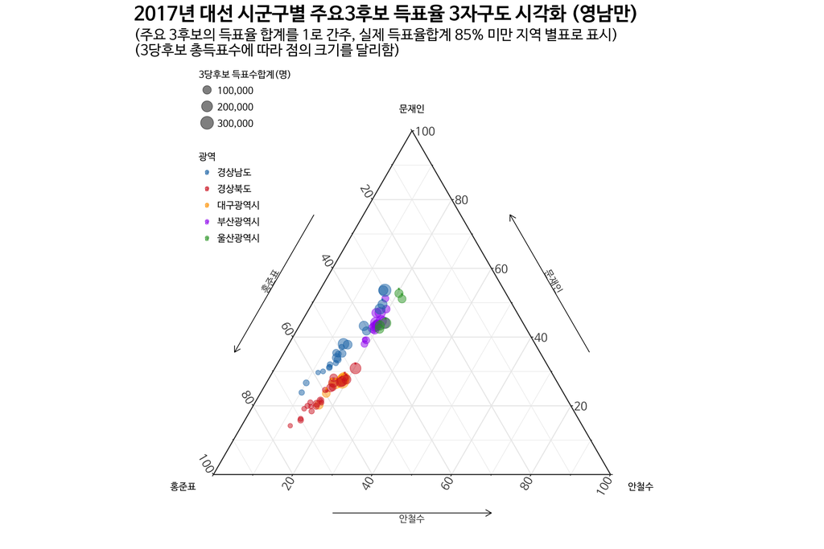

내친김에 전체 시군구 대비해서도 해보자. 영호남의 중량감이 다른 지방과 다른 것이 비교적 잘 들어오고, 수도권의 규모도 어느 정도는 전달된다.

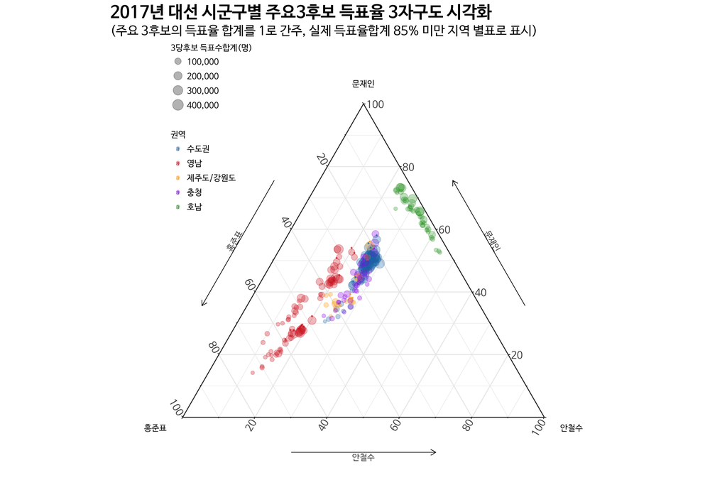